# Abba

INTRODUCTION

This project will examine datasets available at Gapminder. To be more specific, it will take a closer look on the life expectancy of the population from different countries and the influences from other variables. It will also take a look on the development of these variables and the goal is to find trends which are related to a higher life expectancy.

What is Gapminder? "Gapminder is an independent Swedish foundation with no political, religious or economic affiliations. Gapminder is a fact tank, not a think tank. Gapminder fights devastating misconceptions about global development." (https://www.gapminder.org/about-gapminder/)

Posing Questions The following analysis will take a look on the following questions:

How did the world poplation changed over time?

How did the life expectancy and the income per person changed over time?

Is the life expectancy somehow related to the income?

```python
pip install missingno
```

```python
pip install functools
```

```
  Running setup.py clean for functools
Failed to build functools
```

[output not shown]

```
    Running setup.py install for functools: started
    Running setup.py install for functools: finished with status 'error'
```

```python
pip install pycountry
```

```
  Installing build dependencies: started
  Installing build dependencies: finished with status 'done'
  Getting requirements to build wheel: started
  Getting requirements to build wheel: finished with status 'done'
    Preparing wheel metadata: started
    Preparing wheel metadata: finished with status 'done'
```

```python
pip install pycountry_convert
```

```python
#Before we start to analyze this data, the data has to be wrangled and cleaned into a format which can be analyzed. At first, the needed libraries will be imported

import numpy as np #we want to create arrays
import pandas as pd #we want to handle and wrangle data
import matplotlib.pyplot as plt #for plots
import seaborn as sns #plot data

from functools import reduce #merge multiple dataframes together

import pycountry #show country codes to country names
import pycountry_convert #convert the country code to the corresponding continent

#show plots inside this notebook
%matplotlib inline
%config InlineBackend.figure_format = 'retina' #get better plot quality
```

```python
#we want to import the data and look at the general shape
#read population csv
population = pd.read_csv('/Users/NCC/Downloads/population_total.csv')
```

```python
#show head of the created dataframe
population.head()
```

|  | country | 1800 | 1801 | 1802 | 1803 | 1804 | 1805 | 1806 | 1807 | 1808 | ... | 2091 | 2092 | 2093 | 2094 | 2095 | 2096 | 2097 | 2098 | 2099 | 2100 |
| --- | --- | --- | --- | --- | --- | --- | --- | --- | --- | --- | --- | --- | --- | --- | --- | --- | --- | --- | --- | --- | --- |
| 0 | Afghanistan | 3.28M | 3.28M | 3.28M | 3.28M | 3.28M | 3.28M | 3.28M | 3.28M | 3.28M | ... | 76.6M | 76.4M | 76.3M | 76.1M | 76M | 75.8M | 75.6M | 75.4M | 75.2M | 74.9M |
| 1 | Angola | 1.57M | 1.57M | 1.57M | 1.57M | 1.57M | 1.57M | 1.57M | 1.57M | 1.57M | ... | 168M | 170M | 172M | 175M | 177M | 179M | 182M | 184M | 186M | 188M |
| 2 | Albania | 400k | 402k | 404k | 405k | 407k | 409k | 411k | 413k | 414k | ... | 1.33M | 1.3M | 1.27M | 1.25M | 1.22M | 1.19M | 1.17M | 1.14M | 1.11M | 1.09M |
| 3 | Andorra | 2650 | 2650 | 2650 | 2650 | 2650 | 2650 | 2650 | 2650 | 2650 | ... | 63k | 62.9k | 62.9k | 62.8k | 62.7k | 62.7k | 62.6k | 62.5k | 62.5k | 62.4k |
| 4 | United Arab Emirates | 40.2k | 40.2k | 40.2k | 40.2k | 40.2k | 40.2k | 40.2k | 40.2k | 40.2k | ... | 12.3M | 12.4M | 12.5M | 12.5M | 12.6M | 12.7M | 12.7M | 12.8M | 12.8M | 12.9M |

5 rows × 302 columns

With the actual shape of the data, we could easily compare different years of the given data, which we should remember for later. On the other hand the data is not tidy enough to make good visializations or calculations. The next step will handle this problem by melting the dataframe, so that each year will be an own row. The dataframe will also be sorted by the country name and year.

```python
#melt the dataframe to get tidy data
population_melt = pd.melt(population, id_vars=["country"], var_name="year", value_name= "population")

#sort values by country and year
population_melt.sort_values(["country", "year"], inplace = True)

#show the head of the dataframe
population_melt.head()
```

|  | country | year | population |
| --- | --- | --- | --- |
| 0 | Afghanistan | 1800 | 3.28M |
| 197 | Afghanistan | 1801 | 3.28M |
| 394 | Afghanistan | 1802 | 3.28M |
| 591 | Afghanistan | 1803 | 3.28M |
| 788 | Afghanistan | 1804 | 3.28M |

Now this process will be repeated for the life expectancy.

```python
#read life expectancy csv
life_expectancy = pd.read_csv('/Users/NCC/Downloads/life_expectancy_years.csv')
```

```python
life_expectancy.head()
```

|  | country | 1800 | 1801 | 1802 | 1803 | 1804 | 1805 | 1806 | 1807 | 1808 | ... | 2091 | 2092 | 2093 | 2094 | 2095 | 2096 | 2097 | 2098 | 2099 | 2100 |
| --- | --- | --- | --- | --- | --- | --- | --- | --- | --- | --- | --- | --- | --- | --- | --- | --- | --- | --- | --- | --- | --- |
| 0 | Afghanistan | 28.2 | 28.2 | 28.2 | 28.2 | 28.2 | 28.2 | 28.1 | 28.1 | 28.1 | ... | 75.5 | 75.7 | 75.8 | 76.0 | 76.1 | 76.2 | 76.4 | 76.5 | 76.6 | 76.8 |
| 1 | Angola | 27.0 | 27.0 | 27.0 | 27.0 | 27.0 | 27.0 | 27.0 | 27.0 | 27.0 | ... | 78.8 | 79.0 | 79.1 | 79.2 | 79.3 | 79.5 | 79.6 | 79.7 | 79.9 | 80.0 |
| 2 | Albania | 35.4 | 35.4 | 35.4 | 35.4 | 35.4 | 35.4 | 35.4 | 35.4 | 35.4 | ... | 87.4 | 87.5 | 87.6 | 87.7 | 87.8 | 87.9 | 88.0 | 88.2 | 88.3 | 88.4 |
| 3 | Andorra | NaN | NaN | NaN | NaN | NaN | NaN | NaN | NaN | NaN | ... | NaN | NaN | NaN | NaN | NaN | NaN | NaN | NaN | NaN | NaN |
| 4 | United Arab Emirates | 30.7 | 30.7 | 30.7 | 30.7 | 30.7 | 30.7 | 30.7 | 30.7 | 30.7 | ... | 82.4 | 82.5 | 82.6 | 82.7 | 82.8 | 82.9 | 83.0 | 83.1 | 83.2 | 83.3 |

5 rows × 302 columns

```python
#melt the dataframe to get tidy data
life_expectancy_melt = pd.melt(life_expectancy, id_vars = ["country"], var_name = 'year', value_name = 'life_expectancy')

#sort values by country and year
life_expectancy_melt.sort_values(["country", "year"], inplace = True)

#show the head of the dataframe
life_expectancy_melt.head()
```

|  | country | year | life_expectancy |
| --- | --- | --- | --- |
| 0 | Afghanistan | 1800 | 28.2 |
| 195 | Afghanistan | 1801 | 28.2 |
| 390 | Afghanistan | 1802 | 28.2 |
| 585 | Afghanistan | 1803 | 28.2 |
| 780 | Afghanistan | 1804 | 28.2 |

Although it's sometimes good to have each metric in one dataframe, it is needed for this analysis to create a dataframe with multiple metrics, because we are looking for relationships between this data. Therefore, we have to merge the melted dataframe together into one. Since the size of the population will be considered in most parts of the analysis, it will be used as "starting dataframe" for the merging process

```python
#merge the two dataframes together on country and year
df_full = pd.merge(population_melt, life_expectancy_melt, on =["country", "year"], how ='left')
```

```python
#show the head of the dataframe
df_full.head()
```

|  | country | year | population | life_expectancy |
| --- | --- | --- | --- | --- |
| 0 | Afghanistan | 1800 | 3.28M | 28.2 |
| 1 | Afghanistan | 1801 | 3.28M | 28.2 |
| 2 | Afghanistan | 1802 | 3.28M | 28.2 |
| 3 | Afghanistan | 1803 | 3.28M | 28.2 |
| 4 | Afghanistan | 1804 | 3.28M | 28.2 |

```python
#show the info of the dataframe
df_full.info()
```

```
<class 'pandas.core.frame.DataFrame'>
Int64Index: 59297 entries, 0 to 59296
Data columns (total 4 columns):
 #   Column           Non-Null Count  Dtype
---  ------           --------------  -----
 0   country          59297 non-null  object
 1   year             59297 non-null  object
 2   population       59297 non-null  object
 3   life_expectancy  56616 non-null  float64
dtypes: float64(1), object(3)
memory usage: 2.3+ MB
```

```python
pip install missingno
```

```python
import missingno as ms #plot missing data
```

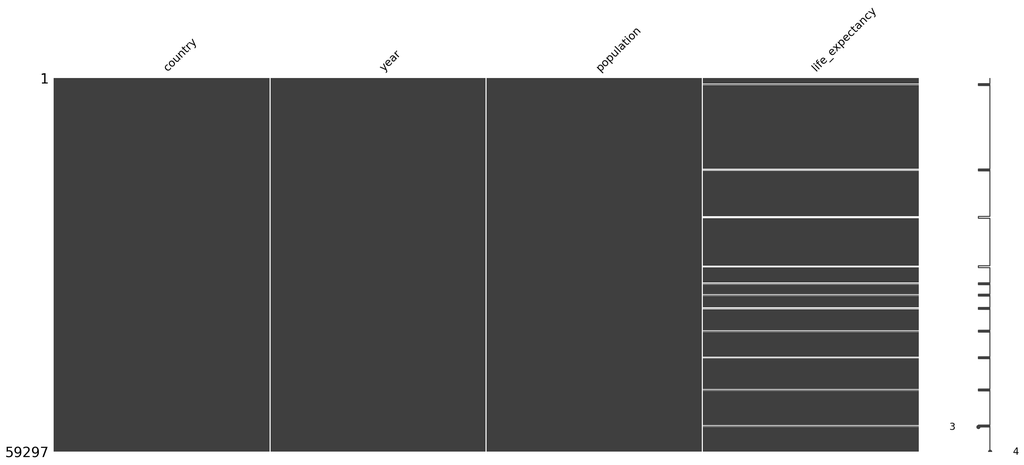

```python
#plot the missing data of the dataset
ms.matrix(df_full);
```

It looks like the missing rows are always multiple rows next to each other, so there maybe are specific countries missing. Before we go on with handling the missing data, we will create a function to generally merge the gapminder data into one dataframe, which will be done in the next cell.

```python
def melt_df(df, valname):
    """
    INPUT:
        df: list of dataframes,
        valname: valuename as string

    OUTPUT:
        list with melted dataframes (by country and year)
    """
    #create list
    df_func = []

    #loop over list of df
    for i, x in enumerate(df):
        df_melt = pd.melt(df[i], id_vars = ["country"], var_name = 'year', value_name = valname[i])
        df_melt.sort_values(["country", "year"], inplace = True)

        #append to created list
        df_func.append(df_melt)
    return df_func
```

```python
dataframes = [population, life_expectancy]
value_names = ["population", "life_expectancy"]

df_func = melt_df(dataframes, value_names)
```

```python
df_func[1].head()
```

|  | country | year | life_expectancy |
| --- | --- | --- | --- |
| 0 | Afghanistan | 1800 | 28.2 |
| 195 | Afghanistan | 1801 | 28.2 |
| 390 | Afghanistan | 1802 | 28.2 |
| 585 | Afghanistan | 1803 | 28.2 |
| 780 | Afghanistan | 1804 | 28.2 |

It worked and together with the "reduce" function it is possible to merge multiple metrics with less effort/writing into one dataframe.

```python
#https://stackoverflow.com/questions/23668427/pandas-three-way-joining-multiple-dataframes-on-columns

#reduces the melted dataframes in our list to one dataframe via merge
df_all = reduce(lambda left,right: pd.merge(left,right,on =["country", "year"], how = 'left'), df_func)
```

```python
df_all.head()
```

|  | country | year | population | life_expectancy |
| --- | --- | --- | --- | --- |
| 0 | Afghanistan | 1800 | 3.28M | 28.2 |
| 1 | Afghanistan | 1801 | 3.28M | 28.2 |
| 2 | Afghanistan | 1802 | 3.28M | 28.2 |
| 3 | Afghanistan | 1803 | 3.28M | 28.2 |
| 4 | Afghanistan | 1804 | 3.28M | 28.2 |

For the final step of creating the "base data", all the necessary data will be loaded and merged into one dataframe.

The necessary data contains: the population, the life expectancy, the income per person, the sugar consume per person and the alcohol consume per person.

```python
#read in all the necessary *.csv
population = pd.read_csv('/Users/NCC/Downloads/population_total.csv')
life_expectancy = pd.read_csv('/Users/NCC/Downloads/life_expectancy_years.csv')
income_per_person = pd.read_csv('/Users/NCC/Downloads/income_per_person_gdppercapita_ppp_inflation_adjusted.csv')
sugar_cons = pd.read_csv('/Users/NCC/Downloads/sugar_per_person_g_per_day.csv')
alc_cons = pd.read_csv('/Users/NCC/Downloads/alcohol_consumption_per_adult_15plus_litres.csv')

#merge the dataframes together like in the steps before
dataframes_all = [population, life_expectancy, income_per_person, sugar_cons, alc_cons]
value_names_all = ["population", "life_expectancy","income_per_person", "sugar_cons", "alc_cons"]

df_func_all = melt_df(dataframes_all, value_names_all)

df_all = reduce(lambda left,right: pd.merge(left,right,on =["country", "year"], how = 'left'), df_func_all)
```

```python
df_all.head(3)
```

|  | country | year | population | life_expectancy | income_per_person | sugar_cons | alc_cons |
| --- | --- | --- | --- | --- | --- | --- | --- |
| 0 | Afghanistan | 1800 | 3.28M | 28.2 | 683 | NaN | NaN |
| 1 | Afghanistan | 1801 | 3.28M | 28.2 | 683 | NaN | NaN |
| 2 | Afghanistan | 1802 | 3.28M | 28.2 | 683 | NaN | NaN |

```python
df_all.info()
```

```
<class 'pandas.core.frame.DataFrame'>
Int64Index: 59297 entries, 0 to 59296
Data columns (total 7 columns):
 #   Column             Non-Null Count  Dtype
---  ------             --------------  -----
 0   country            59297 non-null  object
 1   year               59297 non-null  object
 2   population         59297 non-null  object
 3   life_expectancy    56616 non-null  float64
 4   income_per_person  48945 non-null  object
 5   sugar_cons         8973 non-null   float64
 6   alc_cons           404 non-null    float64
dtypes: float64(3), object(4)
memory usage: 3.6+ MB
```

Looking at the info of the newly created dataframe, we can see that there is alot more missing data than before. Also the "year" column is a string, which should be transformed into an integer, because we will create bins based on the years later. Also the income_per_person column should be transformed into an integer. The sugar_cons is in gramm, so it can also be transformed into an integer.

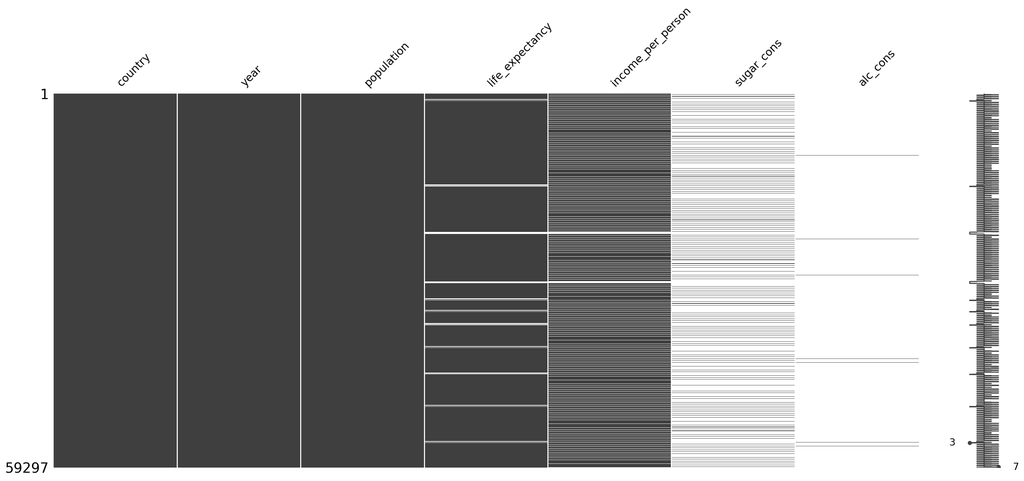

```python
ms.matrix(df_all);
```

The easiest way handling the missing data would be to just drop all the missing data. But it should be avoided in this case, because it would otherwise create an "inconsistency". For example when just 24/50 datapoints of one country are missing, and we take the sum over all countries afterwards, the considered data will not be consistent over time. So if not that much data is missing for a particular country, we could impute the data with the mean of the specific country, if too much data is missing, the whole country data will be dropped. The next defined function should help getting some clarity.

```python
def df_col_attr(df):
    """
    INPUT:
        df - Dataframe
    OUTPUT:
        print statements with the chosen metrics (Duplicates, Min/Max Values, Year Span, Unique Values)
    """
    print("##### DUPLICATES ######\n")
    print("Number of duplicated rows:", sum(df.duplicated()),"\n")

    print("##### MIN / MAX - VALUES ######\n")
    for x in df.columns:
        print(x, f"- min: {df[x].min()}", f"- max: {df[x].max()}")

    print("\n##### YEAR SPAN OF COLUMN #####\n")

    for x in df.columns:
        df_year = df.dropna(subset = [x])
        print(x, f"- Min: {df_year.year.min()}", f" - Max: {df_year.year.max()}")

    print("\n##### UNIQUE - VALUES ######\n")
    for x in df.columns:
        print(x, f"- Number of entries: {df[x].count()} - Number of unique values: {df[x].nunique()}")
```

```python
df_col_attr(df_all)
```

```
##### DUPLICATES ######

Number of duplicated rows: 0

##### MIN / MAX - VALUES ######

country - min: Afghanistan - max: Zimbabwe
year - min: 1800 - max: 2100
population - min: 1.01B - max: 9M
life_expectancy - min: 1.01 - max: 94.4
```

[output not shown]

[output cut: 14 more lines]

[output not shown]

In the next step we should find out which countries have missing data in the specified column and dataframe.

```python
def show_missing_countries(df, column):
    """
    INPUT:
        df - dataframe
        column - string

    OUTPUT:
        returns a list with strings of countries, which has 0 data inside the given dataframe
    """
    list1 = list(df.country.unique())
    list2 = list(df.dropna(subset =[column]).country.unique())

    list3 = [x for x in list1 if x not in list2]
    list3.sort()

    return list3
```

Let's take a closer look on the column with the least rows of data - the "alc_cons" column.

```python
show_missing_countries(df_all, "alc_cons")
```

```
['Congo, Rep.',
 'Holy See',
 'Hong Kong, China',
 'Liechtenstein',
 'Maldives',
 'Marshall Islands',
 'Monaco',
 'Montenegro',
 'Palestine',
 'San Marino',
 'South Sudan',
 'Taiwan']
```

Surprisingly there are not many countries missing. Therefore the missing data probably is connected to a time-component.

```python
#show the value counts of the years, if all the np.nan values are dropped
df_all.dropna(subset=["alc_cons"]).year.value_counts()
```

```
2005    184
2008    184
1994      6
1990      4
1995      4
1993      4
1996      2
1992      2
2000      1
2006      1
2004      1
2003      1
2002      1
2001      1
1988      1
1998      1
1991      1
1989      1
1987      1
1986      1
1985      1
2007      1
Name: year, dtype: int64
```

The most values were measured in 2005 and 2008 - for the analysis, a separate dataframe should be created. This dataframe wil l contain data for the years 2005 and 2008 only.

In the next step this process will be repeated for the "sugar_cons" column.

```python
len(show_missing_countries(df_all, "sugar_cons"))
```

```
27
```

```python
df_all.dropna(subset=["sugar_cons"]).year.value_counts()
```

```
2013    170
2012    170
2011    170
2010    170
2009    170
2008    170
2007    170
2006    170
2018    169
2017    169
2016    169
2015    169
2014    169
2002    168
2000    168
```

[output cut: 44 more lines]

```python
show_missing_countries(df_all, "life_expectancy")
```

```
['Holy See', 'Liechtenstein']
```

For the life_expectancy there are also not many countries missing. In the next cell we will define a function, which prints the amount of missing rows per country.

```python
def show_n_missing(df, column):
    """
    INPUT:
        df - Dataframe
        column - string

    OUTPUT:
        prints the country names and the corresponding number of missing values
        returns a list of strings with countrynames of countries with missing values
    """
    missing = []
    for x in list((df["country"]).unique()):
        n_missing = sum(df[df["country"] == x][column].isnull())

        if n_missing > 0:
            missing.append(x)
            print(x, "-", n_missing)

    return missing
```

```python
show_n_missing(df_all, "life_expectancy");
```

```
Andorra - 231
Dominica - 231
Holy See - 301
Liechtenstein - 301
Marshall Islands - 231
Monaco - 231
Nauru - 231
Palau - 231
San Marino - 231
St. Kitts and Nevis - 231
Tuvalu - 231
```

```python
show_missing_countries(df_all, "income_per_person")
```

```
['Holy See', 'Liechtenstein']
```

```python
show_n_missing(df_all, "income_per_person");
```

```
Afghanistan - 50
Albania - 50
Algeria - 50
Andorra - 50
Angola - 50
Antigua and Barbuda - 50
Argentina - 50
Armenia - 50
Australia - 50
Austria - 50
Azerbaijan - 50
Bahamas - 50
Bahrain - 50
Bangladesh - 50
Barbados - 50
Belarus - 50
Belgium - 50
Belize - 50
Benin - 50
Bhutan - 50
Bolivia - 50
Bosnia and Herzegovina - 50
Botswana - 50
Brazil - 50
Brunei - 50
Bulgaria - 50
Burkina Faso - 50
Burundi - 50
Cambodia - 50
Cameroon - 50
Canada - 50
Cape Verde - 50
Central African Republic - 50
Chad - 50
Chile - 50
China - 50
Colombia - 50
Comoros - 50
Congo, Dem. Rep. - 50
Congo, Rep. - 50
```

[output cut: 142 more lines]

```
Turkmenistan - 50
Tuvalu - 50
Uganda - 50
Ukraine - 50
United Arab Emirates - 50
United Kingdom - 50
United States - 50
Uruguay - 50
Uzbekistan - 50
Vanuatu - 50
Venezuela - 50
Vietnam - 50
Yemen - 50
Zambia - 50
Zimbabwe - 50
```

Also the pattern of missing data looks regular.

Now the following data cleaning and wrangling steps will be done:

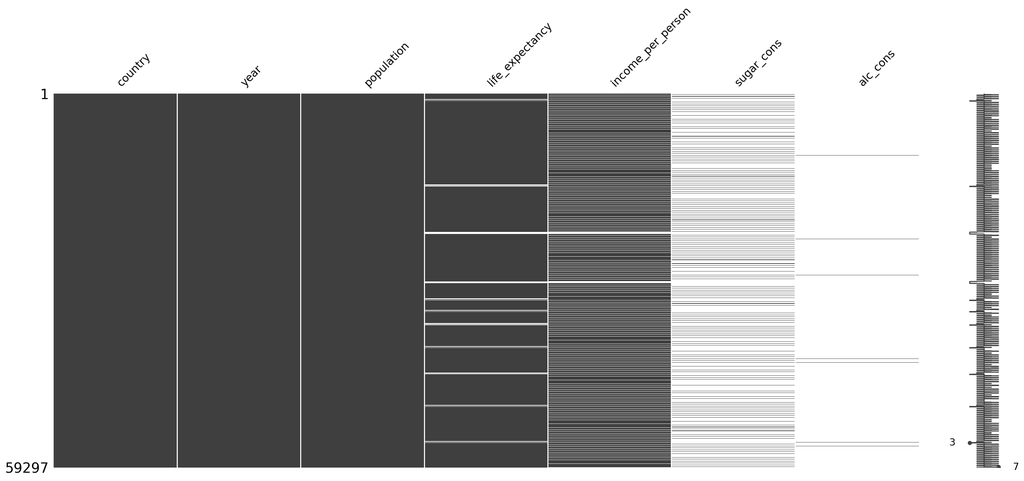

```python
ms.matrix(df_all);
```

At first, the countries with missing data in the column "life_expectancy" will be dropped.

```python
#https://stackoverflow.com/questions/13851535/how-to-delete-rows-from-a-pandas-dataframe-based-on-a-conditional-expression
#https://stackoverflow.com/questions/12096252/use-a-list-of-values-to-select-rows-from-a-pandas-dataframe

#drop all the countries with missing values
missing_val = show_n_missing(df_all, "life_expectancy");
df_all = df_all.drop(df_all[df_all["country"].isin(missing_val)].index)
```

```
Andorra - 231
Dominica - 231
Holy See - 301
Liechtenstein - 301
Marshall Islands - 231
Monaco - 231
Nauru - 231
Palau - 231
San Marino - 231
St. Kitts and Nevis - 231
Tuvalu - 231
```

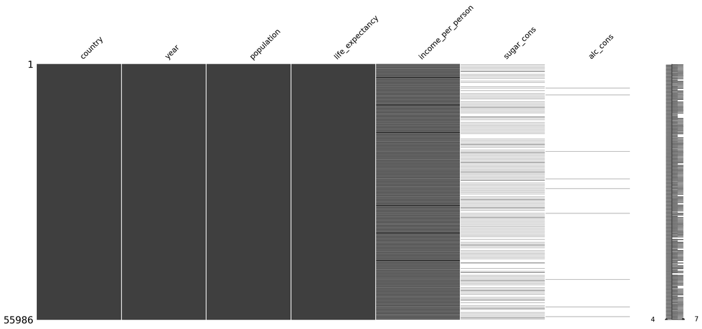

```python
ms.matrix(df_all);
```

```python
#transform column datatypes to int64
df_all.income_per_person = df_all.income_per_person.astype('int64')
df_all.year = df_all.year.astype('int64')
```

[output not shown]

```python
df_all.info()
```

```
<class 'pandas.core.frame.DataFrame'>
Int64Index: 55986 entries, 0 to 59296
Data columns (total 7 columns):
 #   Column             Non-Null Count  Dtype
---  ------             --------------  -----
 0   country            55986 non-null  object
 1   year               55986 non-null  object
 2   population         55986 non-null  object
 3   life_expectancy    55986 non-null  float64
 4   income_per_person  46686 non-null  object
 5   sugar_cons         8857 non-null   float64
 6   alc_cons           392 non-null    float64
dtypes: float64(3), object(4)
memory usage: 3.4+ MB
```

Now separate dataframes for the population, the income, the sugar consumption and also the alcohol consumption will be created. They all share the columns "country", "year" and "population".

```python
#create new dataframes as copies of the df_all dataframe

#create a filtered copy of the df_all dataframe and save it as *.csv without index
df_popul = df_all[["country", "year", "population"]].copy()
df_income = df_all[["country", "year", "population", "life_expectancy", "income_per_person"]].copy()
df_sugar_cons = df_all[["country", "year", "population", "life_expectancy", "sugar_cons"]].copy()
df_alc_cons = df_all[["country", "year", "population", "life_expectancy", "alc_cons"]].copy()
```

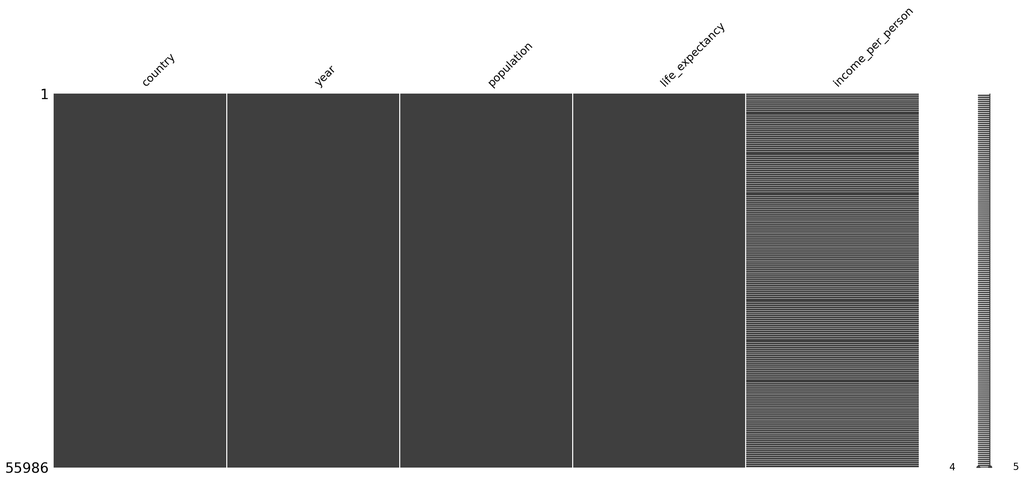

```python
ms.matrix(df_income);
```

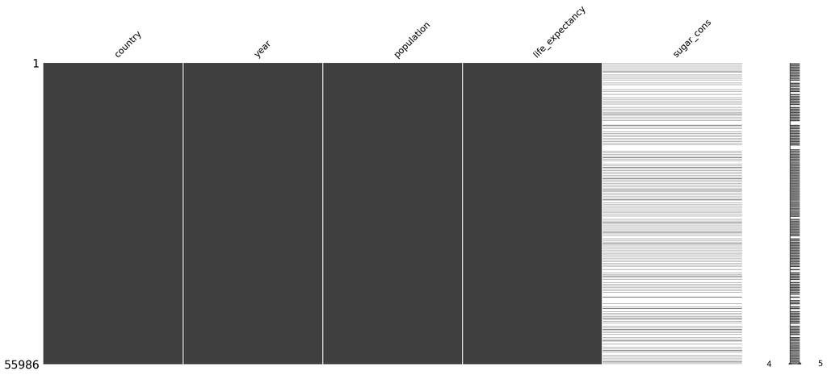

```python
ms.matrix(df_sugar_cons);
```

At first, countries, which were added to the dataset after 1991, will be dropped.

```python
#create a list of countries which had data in the year 1961
countries_1991 = list(df_sugar_cons[df_sugar_cons["year"] == 1991].dropna(subset = ["sugar_cons"]).country.unique())
```

```python
#drop all the countries which had no data in 1961

#https://stackoverflow.com/questions/19960077/how-to-implement-in-and-not-in-for-pandas-dataframe
df_sugar_cons = df_sugar_cons.drop(df_sugar_cons[~df_sugar_cons["country"].isin(countries_1991)].index)
```

```python
ms.matrix(df_sugar_cons);
```

[output not shown]

There is still some data missing after the last step. To go on, the dataframe will be cut from 1961 - 2013

```python
#limit the dataframe to the years 1961 - 2013
df_sugar_cons = df_sugar_cons[(df_sugar_cons.year >= 1961) & (df_sugar_cons.year < 2014)]
```

```python
ms.matrix(df_sugar_cons);
```

[output not shown]

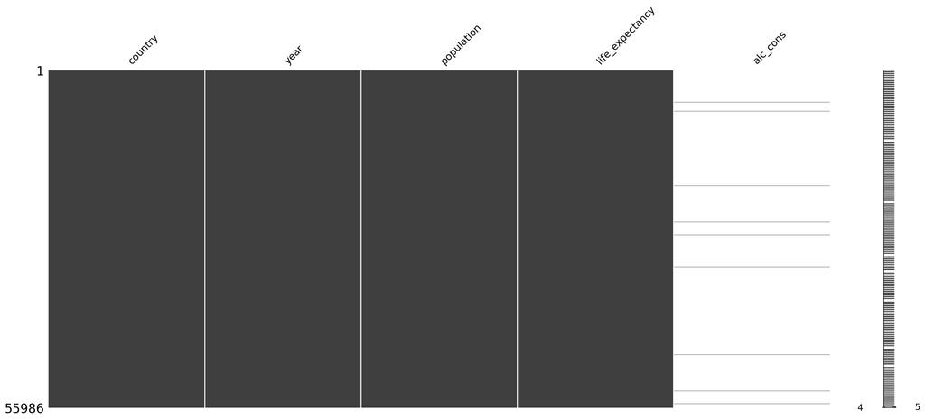

```python
ms.matrix(df_alc_cons);
```

```python
df_alc_cons.head()
```

|  | country | year | population | life_expectancy | alc_cons |
| --- | --- | --- | --- | --- | --- |
| 0 | Afghanistan | 1800 | 3.28M | 28.2 | NaN |
| 1 | Afghanistan | 1801 | 3.28M | 28.2 | NaN |
| 2 | Afghanistan | 1802 | 3.28M | 28.2 | NaN |
| 3 | Afghanistan | 1803 | 3.28M | 28.2 | NaN |
| 4 | Afghanistan | 1804 | 3.28M | 28.2 | NaN |

The next step is to create a new dataframe which only contains the data for the years 2005 and 2008.

```python
df_alc_cons = df_alc_cons[(df_alc_cons.year == 2005 )| (df_alc_cons.year == 2008)]
```

```python
ms.matrix(df_alc_cons);
```

[output not shown]

Now there is still some data missing, therefore the countries with missing data will be dropped.

```python
show_missing_countries(df_alc_cons, "alc_cons")
```

```
[]
```

```python
missing_val = show_n_missing(df_alc_cons, "alc_cons");
df_alc_cons = df_alc_cons.drop(df_alc_cons[df_alc_cons["country"].isin(missing_val)].index)
```

```python
ms.matrix(df_alc_cons);
```

[output not shown]

```python
#save the cleaned data into *.csv files
df_popul.to_csv("df_popul.csv", index = False)
df_income.to_csv("income_clean.csv", index = False)
df_sugar_cons.to_csv("sugar_cons_clean.csv", index = False)
df_alc_cons.to_csv("alc_cons_clean.csv", index = False)
```

EXPLORATORY DATA ANALYSIS

Question 1: How did the world population change over time?

```python
df_popul = pd.read_csv("df_popul.csv")
```

```python
df_popul.head()
```

|  | country | year | population |
| --- | --- | --- | --- |
| 0 | Afghanistan | 1800 | 3.28M |
| 1 | Afghanistan | 1801 | 3.28M |
| 2 | Afghanistan | 1802 | 3.28M |
| 3 | Afghanistan | 1803 | 3.28M |
| 4 | Afghanistan | 1804 | 3.28M |

All the gapminder data has basically the same shape of time series. A lot of this data can be plotted with a lineplot, so in the next four cells several functions will be defined to turn the plotting part into an one-liner to make the future extension of this project more easy.

The graph should contain the following:

A lineplot showing the change over time The chosen bins, including the delta between the bins The axis labels should be dependent on the data and function which was be used to aggregate the data Also I want to keep the customizability, so the y-data labels should be movable, there should be a faktor to change the labels of the plotted data and also the bin size should be variable. To do so, the first function calculates the bins and adds the bin-names to the chosen dataframe. The next function aggregates (sum or mean) the data and calculates the data on and between the bin edges. Also it collects some general data for plotting. The third function is responsible for the plotting part, dependent on the results of the functions before and the last function handles the communication between this functions. This is not the final version of these functions because there is some room for improvement, but for the analysis of the chosen the functions works well.

```python
def add_bins(df, span = 25, start_value = None, end_value = None):
    """
    INPUT:
        df - dataframe to add the bins
        span - integer, distance between the borders of the edges
        start_value - integer, first year
        end_value - integer, last year

    OUTPUT:
        bin_edges - list of bin edges as integers, which can be used with pd.cut
        bin_names - list of strings with bin names
        start_value - returns the input start_value
        end_value - returs the input end_value
    """

    #if no values are specified, take the min and max years of the given dataframe
    if start_value == None:
        start_value = min(df.year)

    if end_value == None:
        end_value = max(df.year)

    #create the edges of the bins and take the index 0 and reduce it -1, so that pd.cut takes the start value into its calculation
    bin_edges = [x for x in range(start_value,end_value, span)]
    bin_edges.append(end_value)
    bin_edges[0] = bin_edges[0] - 1

    bin_names = []

    #join the bin edges together with a "-"
    for i, x in enumerate(bin_edges):
        try:
            bin_names.append(" - ".join([str(bin_edges[i] + 1), str(bin_edges[i+1])]))
        except:
            pass
     #create and add the "bins" column to the given df with bin_names
    df["bins"] = pd.cut(df["year"], bin_edges, labels = bin_names)

    return bin_edges, bin_names, start_value, end_value
```

```python
def prepare_plotdata(df, feature, bin_edges, faktor = 1, func = "sum"):
    """
    INPUT:
        df - dataframe with the added column "bins"
        feature - string, columnname which should be prepared
        bin_edges - list of bin_edges, created with func "add_bins"
        faktor - integer, the calculated data will be divided by this factor for better overview in the plot
        func - can be anything, if func is not "sum", it will automatically take the mean of the feature

    OUTPUT:
        bin_vales - dataframe based on the input dataframe, grouped after the created bins and added with information like the
                    feature value of the first year, the second_year, the change in the feature and the position of the labels
                    inside the plot
        year_data - dataframe grouped by years
    """

    #group the data by years
    if func == "sum":
        year_data = df.groupby("year", as_index = False).sum()
    else:
        year_data = df.groupby("year", as_index = False).mean()

    #group the data by the created bins
    bin_values = df[["bins", feature]].groupby("bins", as_index = False).sum()

    year_firstbin = []
    year_secondbin = []
    feature_change =  []
    change_y = []
    change_x = []

    #filter the dataframes by the given bin_edges and get the feature values to the corresponding years
    for i, x in enumerate(bin_edges):
        try:
            if bin_edges[i] != 1799:
                val1 = int(year_data[year_data.year == bin_edges[i+1]][feature])
                val2 = int(year_data[year_data.year == bin_edges[i]][feature])
            else:
                val1 = int(year_data[year_data.year == 1825][feature])
                val2 = int(year_data[year_data.year == 1800][feature])

            #append the created lists by the values

            #calculate the feature change
            feature_change.append((val1 - val2)/faktor)

            #the change value should be plotted on the half of the y-value
            change_y.append(val2/2)

            #there are a span of 25 years, so the x value for the change should be the half of it - basically span/2,
            #or (year2 - year1 / 2), will be added later
            change_x.append(bin_edges[i]+12.5)
            year_firstbin.append(val2)
            year_secondbin.append(val1)

        except:
            pass

    #add the data to the bin_values dataframe
    bin_values["feature_change"] = feature_change
    bin_values["change_x"] = change_x
    bin_values["change_y"] = change_y
    bin_values["year_firstbin"] = year_firstbin
    bin_values["year_secondbin"] = year_secondbin

    return bin_values, year_data
```

```python
def plot_data(df, bin_values, feature, start_value, end_value, bin_edges,
              faktor = 1, scale_y = 1.05, scale_y_pos = 1, func = "sum", integer = False, span = 25):
    """
    INPUT:
        df - dataframe
        bin_values - dataframe created with function prepare_plotdata
        feature - the feature which should be plotted
        start_value - integer, starting year
        end_value - integer, ending year
        bin_edges - list of integers with bin edges
        faktor - integer for scaling the data
        scale_y - float to scale the y axis
        scale_y_pos - float to customize the y-label pos
        func - string, pass the used func for axis labeling
        integer - boolean, if True, all values will be turned into integer
        span - integer, distance between years for plotting - will be optimized later

    OUTPUT:
        lineplot

    """

    #create a matplotlib figure and axes
    fig, ax = plt.subplots(figsize = (17,8))

    #https://stackoverflow.com/questions/3899980/how-to-change-the-font-size-on-a-matplotlib-plot
    plt.rcParams.update({'font.size': 11})

    x = df["year"]
    y = df[feature]

    #plot the line
    ax.plot(x,y, color = "steelblue", lw = 4)

     #fill the area between the x - values and 0
    ax.fill_between(x, 0, y, color = "lightgray", alpha = 0.4)

    #plot vertical lines to visualize the bins
    for x in range(start_value,end_value,span):
        y_vline = df[df.year == x][feature]
        ax.plot((x,x),(0,y_vline), color = "black", lw = 2, alpha = 0.7)

    #set the y label of the plot
    ax.set_ylabel(f"{func} of the {feature} (based on countries in this dataset)")
    #set the x label of the plot
    ax.set_xlabel("Year")
    #set the title of the plot
    ax.set_title(f"{feature} development")
    #disable the right and top spine for better look
    ax.spines['right'].set_visible(False)
    ax.spines['top'].set_visible(False)

    #add the "feature change between bins" text to the plot
    for i, x in enumerate(list(bin_values.change_x)):
        if integer == False:
            plot_val_delta = round(float(bin_values.loc[i].feature_change),3)
            plot_year_val = round(float(bin_values.year_secondbin.iloc[i]/faktor),3)
        else:
            plot_val_delta = int(bin_values.loc[i].feature_change)
            plot_year_val = int(bin_values.year_secondbin.iloc[i]/faktor)

        ax.text(x, int(bin_values.iloc[i].change_y),
                s = (u'\u0394' + f" {plot_val_delta}"),horizontalalignment='center')

         #add the value text of the bin_edges
    for i, x in enumerate(bin_edges[1:-1]):

        if integer == False:
            plot_year_val = round(float(bin_values.year_secondbin.iloc[i]/faktor),3)
        else:
            plot_year_val = int(bin_values.year_secondbin.iloc[i]/faktor)

        ax.text(x, int(bin_values.year_secondbin.iloc[i]+scale_y_pos),
                s = f"{plot_year_val}", horizontalalignment='center')


    #set axis limits
    ax.set_xlim(1800, 2018)
    ax.set_ylim(0,max(bin_values.year_secondbin*scale_y))
    #tighten the plot layout
    plt.tight_layout()

    #show the plot (basically not necessary for jupyter but I always put it at the end)
    plt.show()
```